# Papineau Qualifying Paper 1: Norming Study Supplementary Materials

B. Papineau

Last Revised: Wednesday, December 22, 2021

# 1 Introduction

This document contains supplementary material related to my first Qualifying Paper towards the PhD in Linguistics at Stanford University. This is a living document (see last revision date above), but contains the methods and results of my norming study on the gendered interpretations of gender-marked role titles in English.

## 1.1 Methods

### 1.1.1 Participants

100 participants were recruited through the online recruitment platform Prolific. All participants were self-identified L1 English speakers and were born and resided in the United States at the time of participation. None of the participants had participated in the 4-person pilot of the norming study, and the pilot data is not reported here.

### 1.1.2 Experiment

A link to the experiment can be found [here](https://branpap.github.io/gender_processing/experiments/norming_study_one/experiment.html), and is available for the keen reader to click through; results are not stored in any way.

Participants were presented with 39 sentence frames of the structure “Someone is a [role title]”, and were asked to indicate on a seven-point Likert scale how likely they thought it was that the ‘someone’ in question was male or female. The Likert scales were randomized between participants with regard to which end of the scale represented a male response. In each sentence, participants were presented with one of 39 role titles in one of its gendered permutations, such that no participant saw the same lexeme multiple times with different gender markings. All participants saw 13 items of each gender (male/female/neutral).

Role titles were selected from a variety of online guides on avoiding gendered language in English. Of the 39 role titles included, 11 made binary gender distinctions between male and female forms (e.g. *villain* vs. *villainess*), while the remaining 28 make ternary gender distinctions with an additional neutral manifestation (e.g. *congressman* vs. *congresswoman* vs. *congressperson*). The norming items are presented in the table below.

Norming Stimuli Items

Presented by lexeme & gendered forms

| Lexeme | Gendered Forms Male | Gendered Forms Female | Gendered Forms Neutral |
| --- | --- | --- | --- |
| Actor | Actor | Actress | --- |
| Anchor | Anchorman | Anchorwoman | Anchor |
| Assemblyperson | Assemblyman | Assemblywoman | Assemblyperson |
| Bartender | Barman | Barmaid | Bartender |
| Businessperson | Businessman | Businesswoman | Businessperson |
| Camera operator | Cameraman | Camerawoman | Camera operator |
| Chair | Chairman | Chairwoman | Chair |
| Congressperson | Congressman | Congresswoman | Congressperson |
| Craftsperson | Craftsman | Craftswoman | Craftsperson |
| Crewmember | Crewman | Crewwoman | Crewmember |
| Door attendant | Doorman | Doorwoman | Door attendant |
| Emperor | Emperor | Empress | --- |
| Firefighter | Fireman | Firewoman | Firefighter |
| Fisher | Fisherman | Fisherwoman | Fisher |
| Flight attendant | Airline steward | Airline stewardess | Flight attendant |
| Foreperson | Foreman | Forewoman | Foreperson |
| Garbage collector | Garbageman | Garbagewoman | Garbage collector |
| Gentleperson | Gentleman | Gentlewoman | Gentleperson |
| God | God | Goddess | --- |
| Headteacher | Headmaster | Headmistress | Headteacher |
| Heir | Heir | Heiress | --- |
| Hero | Hero | Heroine | --- |
| Horesperson | Horseman | Horsewoman | Horesperson |
| Host | Host | Hostess | --- |
| Hunter | Hunter | Huntress | --- |
| Layperson | Layman | Laywoman | Layperson |
| Mail carrier | Mailman | Mailwoman | Mail carrier |
| Maintenance person | Handyman | Handywoman | Maintenance person |
| Meteorologist | Weatherman | Weatherwoman | Meteorologist |
| Newsboy | Newsboy | Newsgirl | --- |
| Paper carrier | Paperboy | Papergirl | Paper carrier |
| Police officer | Policeman | Policewoman | Police officer |
| Proprieter | Landlord | Landlady | Proprieter |
| Restaurant server | Waiter | Waitress | Restaurant server |
| Salesperson | Salesman | Saleswoman | Salesperson |
| Sorcerer | Sorcerer | Sorceress | --- |
| Stunt double | Stuntman | Stuntwoman | Stunt double |
| Usher | Usher | Usherette | --- |
| Villain | Villain | Villainess | --- |

## 1.2 Results

### 1.2.1 Means by item, inclusive

Presented here are the mean evaluations of all 39 lexemes in each of their gendered permutations. A score of 7 means that the variant was evaluated as being extremely likely to be referring to a female, while a score of 1 indicates that the variant was taken to refer to a male. A midling score reflects an ambiguous (or potentially non-binary) referent.

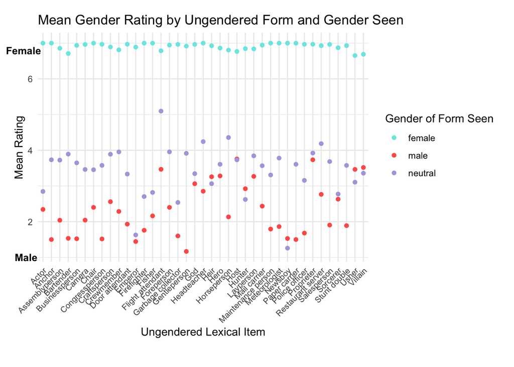

### 1.2.2 Means by item, subsequent experiments only

This graph presents the same values, but includes only the lexical items which were used as critical items in the subsequent experiments.

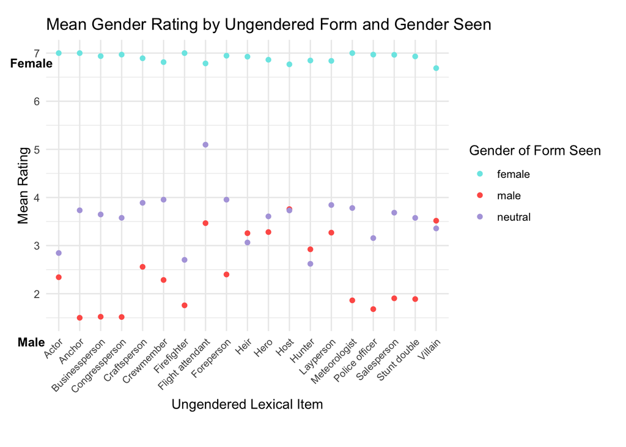